# Lab 4: Exploratory Data Analysis

Yuvraj Jain

February 20, 2023

# Introduction

In this lab assignment, make sure you work in order of the code chunks, and **knit** after you complete each code chunk.

Consider the dataset `Wages1` from the `Ecdat` package.

```
##   exper    sex school     wage
## 1     9 female     13 6.315296
## 2    12 female     12 5.479770
## 3    11 female     11 3.642170
## 4     9 female     14 4.593337
## 5     8 female     14 2.418157
## 6     9 female     14 2.094058
```

This observational dataset records the years experienced, the years schooled, the sex, and the hourly wage for 3,294 workers in 1987. *A Guide to Modern Econometrics* by Marno Verbeek utilizes this data in a linear regression context. According to Marno Verbeek, this data is a subsample from the US National Longitudinal Study. The purpose of this tutorial is to practice the creative process in exploratory data analysis of asking questions and then investigating those questions using visuals and statistical summaries.

As a member of the birth class of 1988, I do not have any clue of what the workforce looked like in 1987. It is your job to apply your detective skills to the information hidden in this data. For future use, utilize the modified dataset`wage` according to the R code below:

```r
wage=as.tibble(Wages1) %>%
  rename(experience=exper) %>%
  arrange(school)
head(wage)
```

```
## # A tibble: 6 × 4
##   experience sex    school  wage
##        <int> <fct>   <int> <dbl>
## 1         18 male        3 5.52
## 2         15 male        4 3.56
## 3         18 male        4 9.10
## 4         10 female      5 0.603
## 5         11 male        5 3.80
## 6         14 male        5 7.50
```

# Part 1: Questions About Variation

### 1.1: Use a figure to find what is the most common number of years of experience found in the data (0.5 Points).

First, use `geom_bar()` to investigate the distribution of level of experience found in `wage`.

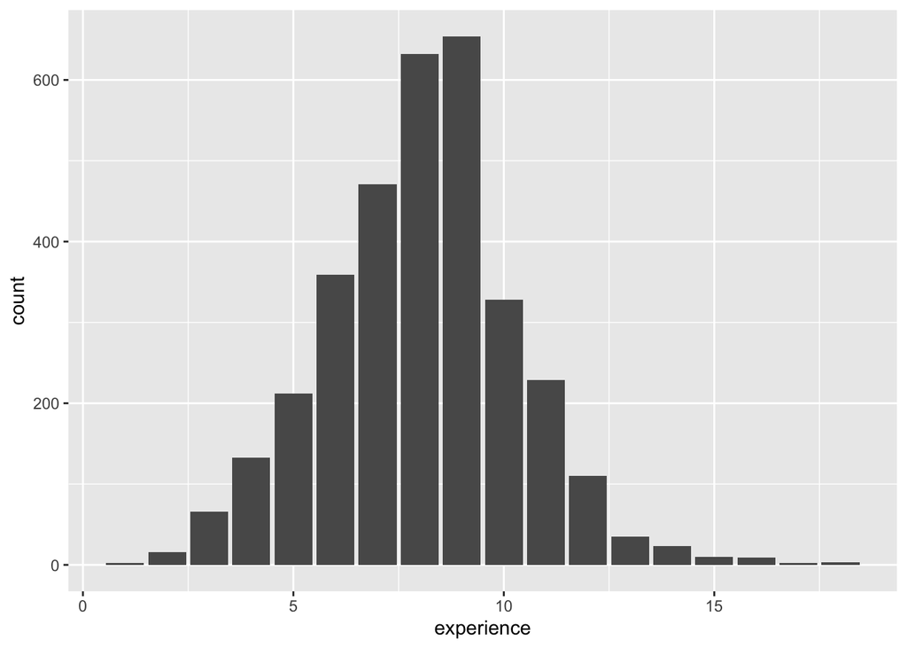

```r
ggplot(data = wage) +
  geom_bar(mapping = aes(x = experience))
```

### 1.2: Use a table to find what is the most common number of years of experience found in the data (1.5 Points).

Use `group_by(experience)` along with the pipe `%>%` to output the most common amount of years of experience along with the number of occurrences found in the data. The most common value for years of experience is 9 and occurs 654 times. Fill in the blanks with the correct answers, and change `eval=True` to `eval=False` and print out the output that led you to your answer.

```r
wage %>%
  group_by(experience) %>%
  summarize(count = n()) %>%
  arrange(desc(count))
```

[output not shown]

### 1.3: Use a figure to find what is the maximum number for years of schooling found in the data. (0.5 Points)

First, use `geom_bar()` to visualize the overall distribution of level of schooling found in the data.

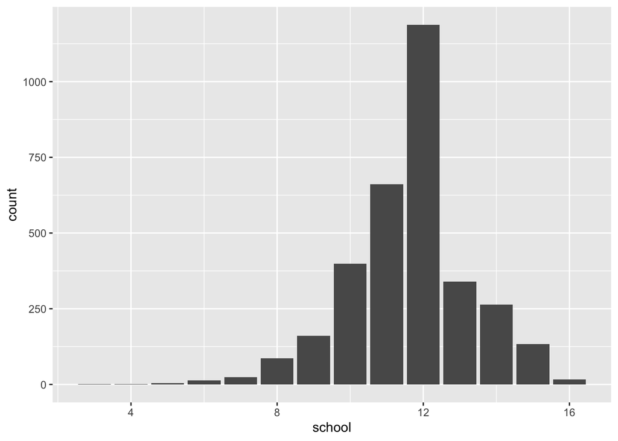

```r
ggplot(data = wage) +
  geom_bar(mapping = aes(x = school))
```

### 1.4: Use a table to find what is the maximum number for years of schooling found in the data. (1.5 Points)

```r
wage %>%
  group_by(school) %>%
  summarize(count = n()) %>%
  arrange(desc(count))
```

```
## # A tibble: 14 × 2
##    school count
##     <int> <int>
##  1     12  1188
##  2     11   661
##  3     10   399
##  4     13   339
##  5     14   264
##  6      9   161
##  7     15   134
##  8      8    86
##  9      7    24
## 10     16    16
## 11      6    14
## 12      5     5
## 13      4     2
## 14      3     1
```

# Part 2: Questions about Covariation

### 2.1: Follow-up to Questions 1-2: Is there a relationship between level of schooling and level of experience? (1 Point)

Use `geom_point()` to display a scatter plot representing the relationship between these two discrete numeric variables. Consider using `alpha=0.1` to indicate where the relationship is represented the best.

The years of experience seem to decrease (increase/decrease) as the years of schooling increases. Is this what you expected to see? yes (yes/no).

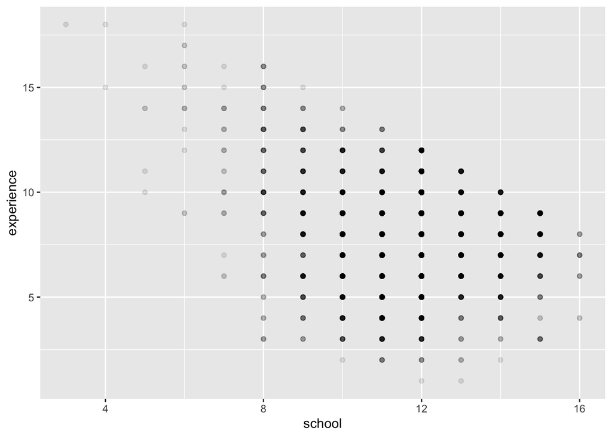

```r
ggplot(data = wage) +
  geom_point(mapping = aes(x = school, y = experience), alpha = 0.1)
```

Question: Practically, what reasons do you hypothesize for this observed relationship? Write your answer in complete sentences below:

I expected to see this because if people are in school, they’re not gaining experience. People who are not in school are actually gaining experience in contrast to people who are going to school during those years. For example, if a person doesn’t go to college but decides to get a job, they will already have at least 4 years of experience compared to people who went to college.

### 2.2: How do hourly wages differ between males and females? (1 Point)

Use `geom_freqpoly()` to compare the distribution of wage of females to the distribution of wage of males.

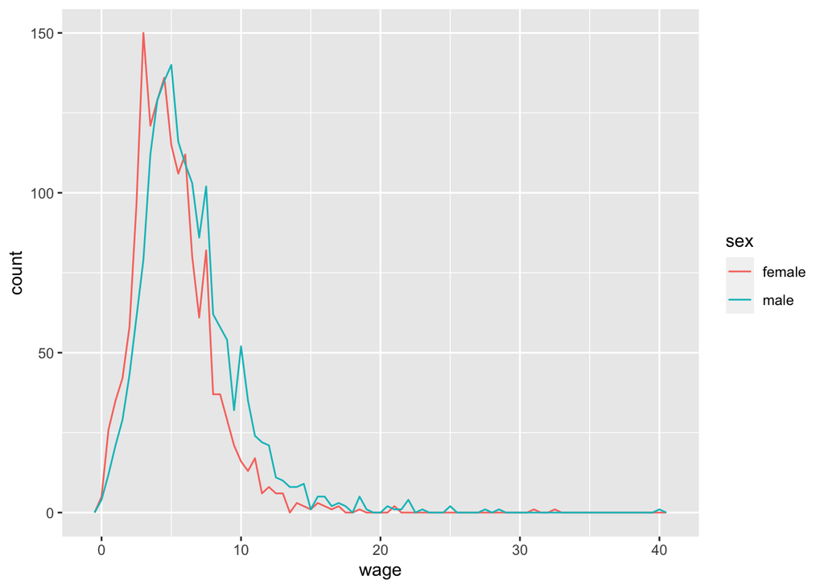

```r
ggplot(data = wage) +
  geom_freqpoly(mapping = aes(x = wage, color = sex), binwidth = 0.5)
```

Question: Where do these distributions look the same and/or where do they differ? Write your answer in complete sentences below:

These distributions look more or less the same after wage > 20; however, for values of wage between 0-20, we can see that there are more males with higher wages and fewer males with lower wages compared to females. In fact, the peak for the count of males occurs at a higher wage when compared to females.

### 2.3: How do hourly wages differ between males and females? (1.5 Points)

Use `group_by()` along with summarize to report the mean `wage`, standard error of `wage`, and 95% confidence interval for the unknown population mean hourly wage for the various levels of `sex`. The standard error is equal to the standard deviation divided by the square root of the sample size. The 95% confidence interval is approximated by obtaining the lower and upper bound of an interval within 2 standard errors of the sample mean. Based on the confidence limits, do we have statistical evidence to say that the average hourly wage for men was different than the average hourly wage for women in 1987? yes (yes/no).

```r
wage %>%
  group_by(sex) %>%
  summarize(n=n(),
            mean=mean(wage),
            se=sd(wage, na.rm = T) / sqrt(n),
            lb=mean-2*se,
            ub=mean+2*se)
```

Question: How would you explain your answer in terms of the confidence intervals that are constructed below? Write your answer in complete sentences below:

At the 95% significance level, there is no intersection of the confidence intervals between males and females. Therefore, we have statsitic evidence to conclude that the average hourly wage for men was different than the average hourly wage for women in 1987.

```r
wage %>%
  group_by(sex) %>%
  summarize(n=n(),mean=mean(wage),se=sd(wage)/sqrt(n),
            lb=mean-2*se,ub=mean+2*se)
```

```
## # A tibble: 2 × 6
##   sex        n  mean     se    lb    ub
##   <fct>  <int> <dbl>  <dbl> <dbl> <dbl>
## 1 female  1569  5.15 0.0726  5.00  5.29
## 2 male    1725  6.31 0.0842  6.14  6.48
```

### 2.4: Does the relationship between hourly wage and years of experience differ between the sexes? (0.5 Points)

Use `geom_point()` along with the option `color=sex` to overlay scatter plots. Does there seem to be a clear distinction between female and male regarding this relationship? yes (yes/no).

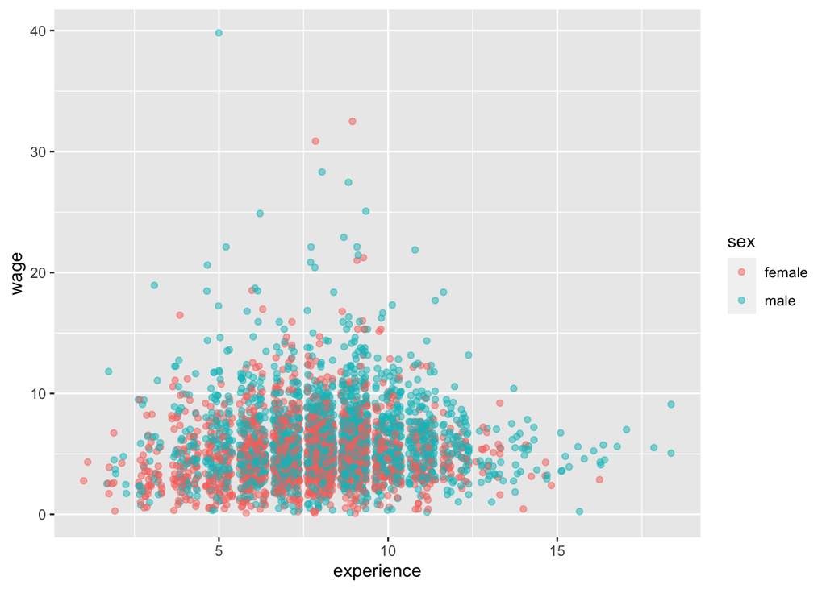

```r
ggplot(data = wage) +
  geom_point(mapping = aes(x = experience, y = wage, color = sex), position = "jitter", alpha = 0.5)
```

### 2.5: Does the relationship between hourly wage and years of schooling differ between the sexes? (0.5 Points)

Repeat the graphic created in Question 4 replacing `x=experience` with `x=school`. Does there seem to be a clear distinction between female and male regarding this relationship? yes (yes/no).

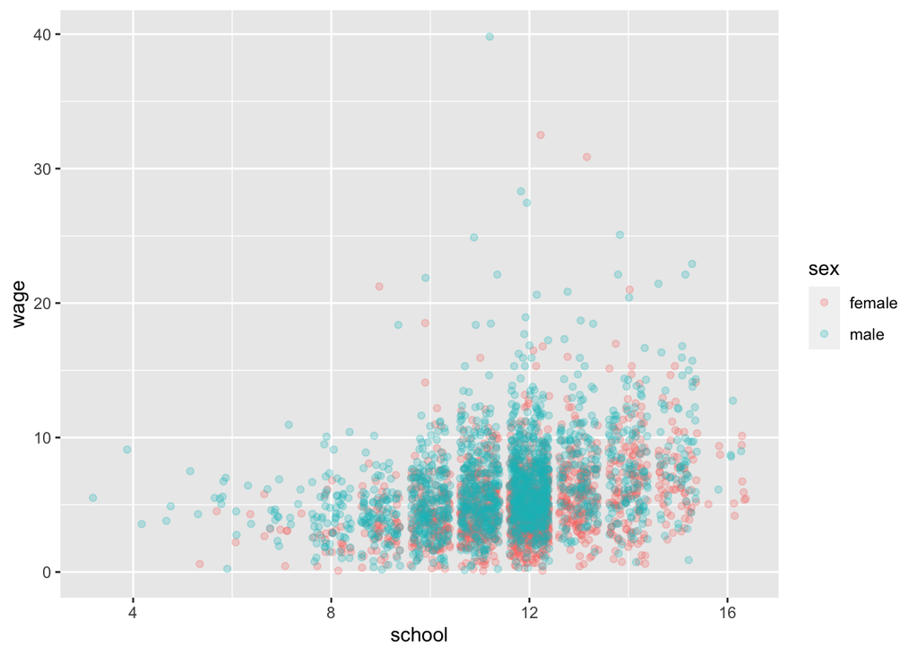

```r
ggplot(data = wage) +
  geom_point(mapping = aes(x = school, y = wage, color = sex), position = "jitter", alpha = 0.25)
```

### 2.6: What is the relationship between hourly wage and the interaction between the years of experience and years of schooling? (0.5 Points)

The graphic below summarizes the average hourly wage for the different combinations of schooling and experience level. The additional `facet_grid(~sex)` makes comparing the relationship of the three key numeric variables between the sexes quite easy.

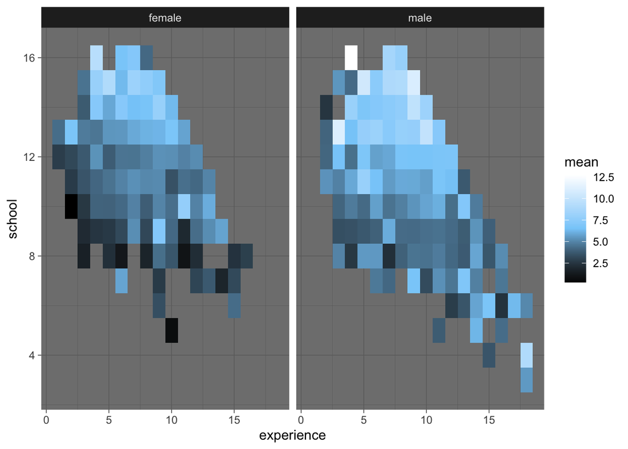

```r
wage %>%
  group_by(experience,school,sex) %>%
  summarize(n=n(),mean=mean(wage)) %>%
  ungroup() %>%
  ggplot() +
    geom_tile(aes(x=experience,y=school,fill=mean)) +
  scale_fill_gradientn(colors=c("black","lightskyblue","white"))+
    facet_grid(~sex) + theme_dark()
```

Question: What are some differences between the sexes regarding this relationship that are apparent in this chart? Write your answer in complete sentences below:

### 2.7: What is the relationship between hourly wage and the interaction between the years of experience and years of schooling? (1 Point)

The next figure is similar to the previous one except that the tile color reflects the standard deviation of wage rather than the mean. Interactions of experience and school levels containing less than or equal to 10 instances are ignored in this image.

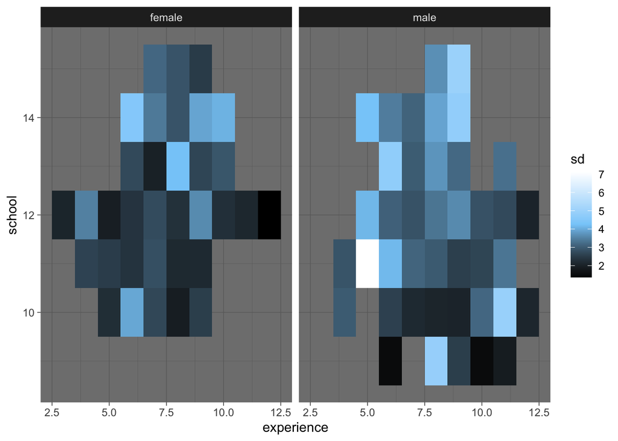

```r
wage %>%
  group_by(experience,school,sex) %>%
  summarize(n=n(),sd=sd(wage)) %>%
  ungroup() %>%
  filter(n>10) %>%
  ggplot() +
  geom_tile(aes(x=experience,y=school,fill=sd)) +
  scale_fill_gradientn(colors=c("black","lightskyblue","white"))+
  facet_grid(~sex) + theme_dark()
```

Question: Which plot is generally darker and what does that imply? Write your answer in complete sentences below:

Question: Specifically for the scenario where a worker has 5 years of experience and 11 years of schooling, what does the extreme contrast between female and male cells imply for this figure? Write your answer in complete sentences below:

Tl;dr: While males used their experience to leverage picking up jobs, females had to spend more time in school to compete for the same jobs.